# Create custom line types

Dag Tanneberg

31 October 2015

## Introduction

Line types are one very efficient way to map discrete variables to the aesthetics of a plot. However, you may quickly run out of alternatives if those variables have more than a handful of possible values. Fortunately, Hadley Wickham’s ggplot2 supports custom line types, and the default line types shown below merely represent quick settings from a more complex set of alternatives.

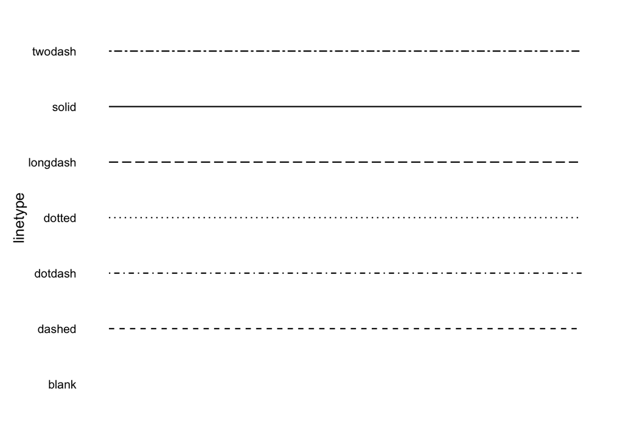

```r
dta <- data.frame(
  line.type = c(
    "blank", "solid", "dashed", "dotted", "dotdash",
    "longdash", "twodash"
  )
)

library('ggplot2')
ggplot(data = dta) +
  geom_segment(
    aes(
      x = 0, xend = 1, y = line.type, yend = line.type,
      linetype=line.type
    )
  ) +
  scale_y_discrete(name="linetype") +
  scale_linetype_identity() +
  theme_minimal() +
  theme(
    axis.text.x = element_blank(),
    axis.ticks = element_blank(),
    axis.title.x = element_blank(),
    panel.grid = element_blank()
  )
```

## Define a custom line type

To define your own line type you must provide a string of length 2, 4, 6, or 8. The longer that string the more complex patterns become possible. Each element of the vector tells ggplot2 about the width of fills and blanks in a new line type. The pattern is FILL BLANK FILL BLANK FILL BLANK FILL BLANK. Valid values range from 1 to 9 with higher numbers indicating more width. The example below plots 7 random line types of length 2.

```r
dta <- expand.grid(1:9, 1:9)
dta[, 'line.type'] <- paste0(dta[, 1], dta[, 2])
head(dta)
```

```
##   Var1 Var2 line.type
## 1    1    1        11
## 2    2    1        21
## 3    3    1        31
## 4    4    1        41
## 5    5    1        51
## 6    6    1        61
```

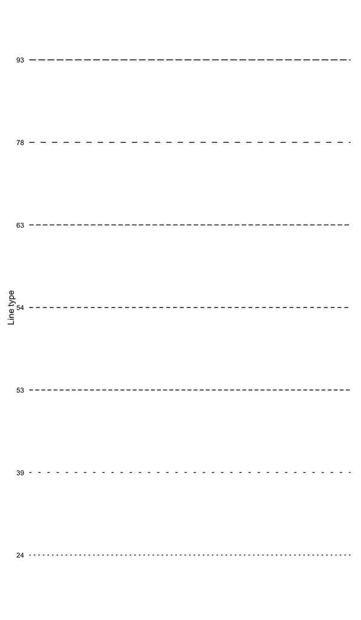

```r
set.seed(15889)
ggplot(data = dta[sample(1:nrow(dta), 7), ]) +
  geom_segment(
    aes(
      x = 0, xend = 1, y = line.type, yend = line.type,
      linetype=line.type
    )
  ) +
  scale_x_continuous(expand = c(0,0)) +
  scale_linetype_identity() +
  labs(y = 'Line type') +
  theme_minimal() +
  theme(
    axis.text.x = element_blank(),
    axis.ticks = element_blank(),
    axis.title.x = element_blank(),
    panel.grid = element_blank()
  )
```

## Note

Another introduction to custom line types is available from [Sape](http://sape.inf.usi.ch/quick-reference/ggplot2/linetype). This resource mentions that ggplot2’s line.type parameter is equivalent to the base plot parameter lty. In other words, you can do the same thing in base R.